# Présentation générale des données

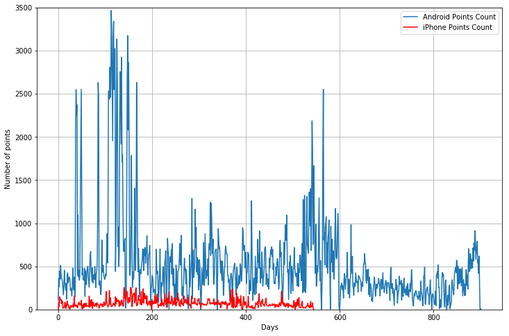

```python
plt.figure(figsize=(12,8))
plt.plot(android_points, '-',label='Android Points Count')
plt.plot(iphone_points, 'r-',label='iPhone Points Count')
plt.grid(True)
plt.ylabel('Number of points')
plt.xlabel('Days')
plt.ylim((0, 3500))
plt.legend(loc='upper right')
#plt.savefig('3-files/comparaisonNbPoints.png')
plt.show()
```

# Nettoyage des données

Deux filtres qui modifient les points :

```
- mean filter
- median filter
```

## Mean filter

Sur une fenêtre de taille 2k+1

$$x_{n} = {\sum\limits_{i=-k}^k x_{n+i} \over 2k+1}.$$

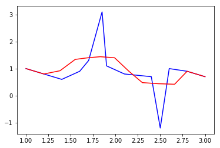

```python
plt.plot(x, y, 'blue', label='1')
plt.plot(xfilt, yfilt, 'red', label='2')
plt.show()
```

## Median filter

Sur une fenêtre de taille 2k+1

$$x_{n} = median [x_{n-k}:x_{n+k}] $$

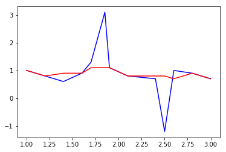

```python
plt.plot(x, y, 'blue', label='1')
plt.plot(xfilt2, yfilt2, 'red', label='2')
plt.show()
```

Le median filter a une meilleure robustesse face aux outliers.

# Application à des données réelles

```python
IFrame('pres-files/filters.html', width=990, height=500)
```

[interactive chart not shown]

## Raffinage du filtrage

Filtres précis sur des points proches spatialement et temporellemet.

Idée :

- séparer les points en segments cohérent temporellement
- adapter le filtre à la densité spatiale de chaque segment

## Nouveau filtre :

- seuil de 400 secondes entre deux segments

Pour chaque segment :

- distance moyenne < 20m => median filter de fenêtre 7
- 20m < distance moyenne < 50m => median filter de fenêtre 5
- 50 < distance moyenne < 150 mètres => mean filter de fenêtre 5

### Comparaison aux données d'origine

```python
IFrame('pres-files/segmented_filter_vs_original.html', width=990, height=500)
```

[interactive chart not shown]

### Comparaison au median filter simple

On compare maintenant notre filtre par segment au median filter simple de fenêtre 5.

```python
IFrame('pres-files/segmented_filter_vs_median.html', width=990, height=500)
```

[interactive chart not shown]

Pistes pour un meilleur raffinage :

- utiliser des filtres heuristiques pour écarter les outliers lorsque la densité est faible (seuil d'accélération)
- adapter la taille de la fenêtre à la densité locale

# Segmentation des données

## Segmentation sur la Vitesse

Notre première intuition était d'utiliser la vitesse pour cette segmentation, avec un règle du type

```
En mouvement : vitesse > threshold
Immobile : vitesse < threshhold
```

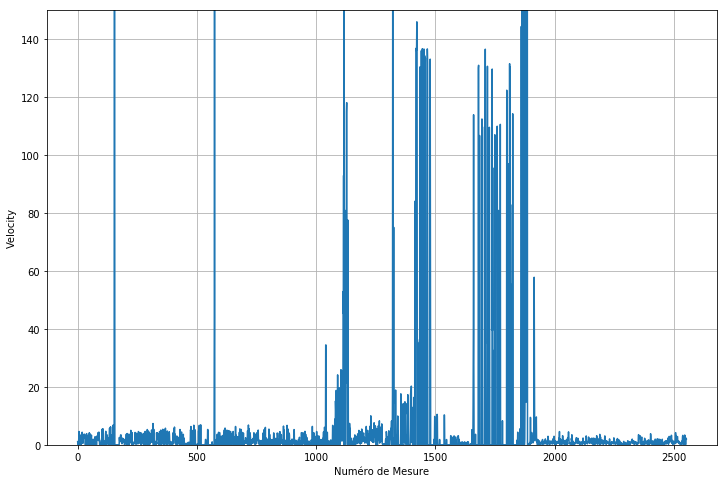

```python
plt.figure(figsize=(12,8))
plt.plot(day1["velocity"])
plt.grid(True)
plt.ylabel('Velocity')
plt.xlabel('Numéro de Mesure')
plt.ylim(0, 150)
plt.show()
```

## Segmentation sur la densité des positions

[figure not shown]

```python
IFrame("pres-files/stay-points-day1.html", width=990, height=500)
```

[interactive chart not shown]

## Filtres heuristiques

```python
IFrame('3-files/meanFilter.html', width=990, height=500)
```

[interactive chart not shown]

### Points d'arrets

```python
IFrame('3-files/immobility.html', width=990, height=500)
```

[interactive chart not shown]

### Filtrage des hautes fréquences

```python
gmap = gmplot.GoogleMapPlotter(45.757589, 4.831689, 15, apikey="AIzaSyDsYwvF3UUxTx8RB40wd4SnUVzfnbW66LM")
gmap.plot(filteredData['latitude'],filteredData['longitude'], 'cornflowerblue', edge_width=3)
gmap.draw("3-files/meanFilter.html")
from IPython.display import IFrame
IFrame('3-files/meanFilter.html', width=990, height=500)
```

[interactive chart not shown]

## Classification des vitesses

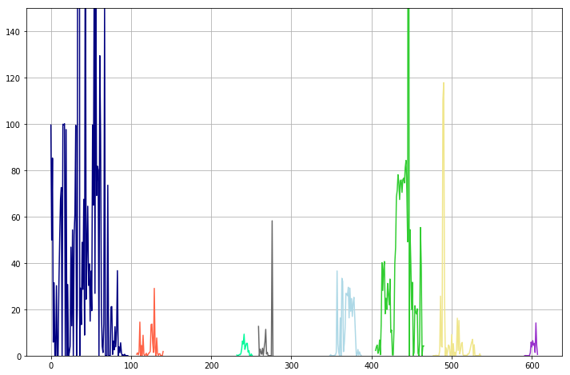

```python
plt.figure(figsize=(12,8))
plt.ylim(0,150)
plt.grid(True)
segment_count = max(stay_point_df2["segment_mouvement"])
for l in range(segment_count):
    segment = stay_point_df2[stay_point_df2['segment_mouvement'] == l]
    segment_mouvement = segment[segment['is_mouvement'] == True ]
    plt.plot(segment_mouvement['velocity'], color=lColors[l%20])
```

### Application à un segment particulier

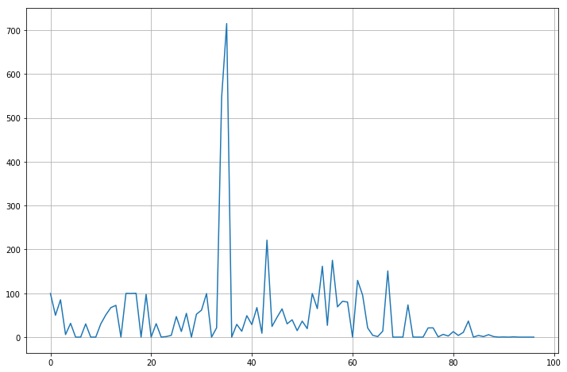

```python
segNum=0
segment = stay_point_df2[stay_point_df2['segment_mouvement'] == segNum]
segment_mouvement = segment[segment['is_mouvement'] == True ]
plt.figure(figsize=(12,8))
plt.grid(True)
plt.plot(segment_mouvement['velocity'])
plt.show()
```

```python
(lK,whitened)=speedClass.applyKMeans(segment_mouvement,k=5)
lBoundiaries=speedClass.getBoundiaries(lK)
lFirstSpeedSegmentation=speedClass.calcFirstSegmentation(lBoundiaries,whitened,bPadd=True)
```

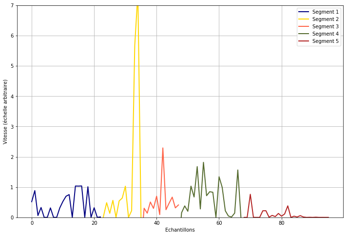

```python
plt.figure(figsize=(12,8))
plt.grid(True)
plt.ylim(0,7)
for ii, plots in enumerate(lFirstSpeedSegmentation):
    plt.plot(plots,lColors[ii%20],linewidth=2,label='Segment '+str(ii+1))
plt.legend()
plt.xlabel('Echantillons')
plt.ylabel('Vitesse (échelle arbitraire)')
plt.show()
```

```python
(l,a)=speedClass.agglomerateSpeedSegments(lFirstSpeedSegmentation)
```

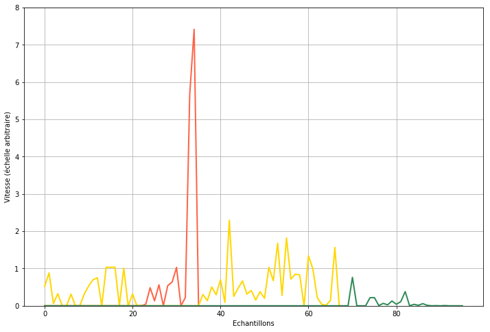

```python
plt.figure(figsize=(12,8))
plt.grid(True)
plt.ylim(0,8)
for ii, plots in enumerate(l):
    plt.plot(plots,colorListSpeed[a[ii]],linewidth=2)
plt.xlabel('Echantillons')
plt.ylabel('Vitesse (échelle arbitraire)')
plt.show()
```

### Application à l'ensemble des segments

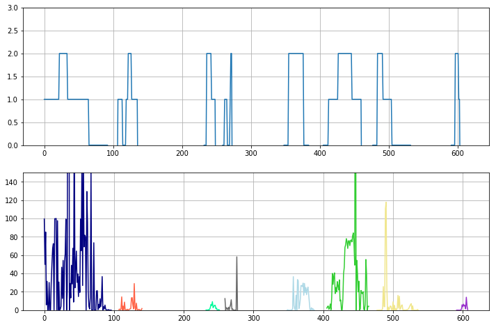

```python
plt.figure(figsize=(12,8))
plt.subplot(211)
plt.plot( stay_point_df2['speedClass'])
plt.ylim(0,3)
plt.grid(True)
plt.subplot(212)
plt.ylim(0,150)
plt.grid(True)
segment_count = max(stay_point_df2["segment_mouvement"])
for l in range(segment_count):
    segment = stay_point_df2[stay_point_df2['segment_mouvement'] == l]
    segment_mouvement = segment[segment['is_mouvement'] == True ]
    plt.plot(segment_mouvement['velocity'], color=lColors[l%20])
```